# Welcome to the Small Group Sessions of Cognitive Neuroscience

This book contains the materials for the small group session of the Cognitive Neuroscience course (Academic year 2526). The overarching aim of these sessions is to gain in-depth knowledge about certain sub-topics in Cognitive Neuroscience which, due to time limitation, cannot be covered in detail in the big group sessions. The final outcome will be a group project in which you will create a podcast-like episode on a subtopic of your chosing within Cognitive Neuroscience.

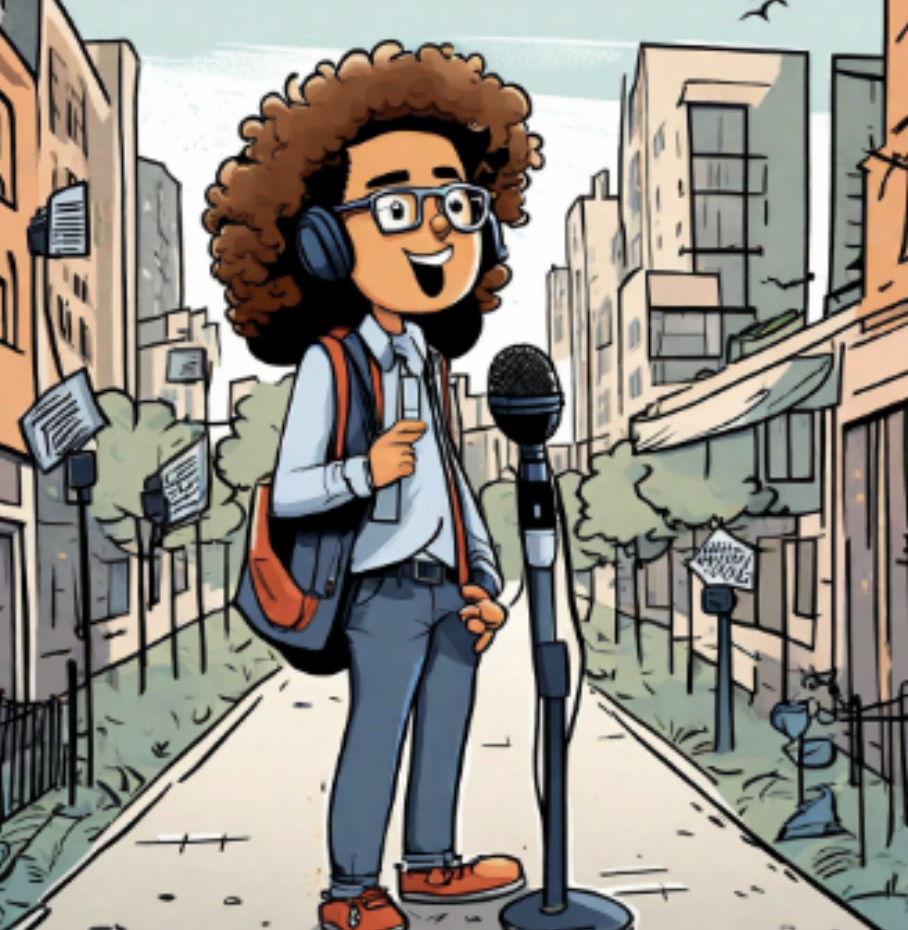

The image of a happy and dynamic podcaster recording in a very bad scenario. Be motivated by this guy, but do not be this guy. Recording outdoors is a very bad idea.

## How to Use This Book

This book is organized week by week, following the course structure. Each chapter contains information about what is to be expected for the corresponding week’s session. Also, throughout the weeks you will find information about concrete milestones and how to deliver them.

Navigate through the chapters using the sidebar or the next/previous buttons at the bottom of each page.

If you have any questions or need further clarification on the course content, assignments, or any technical issues related to podcast production, please do not hesitate to reach out to the course instructors via email or during office hours. We are here to support your learning journey and ensure you have all the resources you need to succeed in this course.

Remember, this course is not just about learning theoretical aspects of Cognitive Neuroscience but also about learning to communicate this knowledge in a creative and practical way. We encourage you to engage actively with the course materials, participate in discussions during the on-site sessions, and bring your unique perspectives to the episodes you will create.

Good luck, and we look forward to hearing your podcasts!